# STA5703 hw 2

Thien Pham

2023-09-17

## Preparing workspace

```r
options(
  digits = 2,   # Just gives 2 significant digits
  scipen = 999, # The larger the value the more it avoids scientific notation when printing
  warn = -1     # Suppress warnings
)
rm(
  list = ls()
)

library(magrittr)
library(ggplot2)
```

Data source: https://www.kaggle.com/datasets/sknaseerhussain/logistic-regression-for-telecom-churn

This data set contains customer data from a telecom company and the goal is to identify variables that could affect churning in order to help retain customers.

Target variable: Churn  
Churn = 1 (likely to leave the provider)  
Churn = 0 (will remain with the provider)

## Loading data, turning target variable into binary

```r
telecom <- readr::read_csv(
  file = "/Users/thienpham/Data Mining/data/telecom.csv",
  col_types = "ccccccccccccccccccccc",
) %>%
  dplyr::mutate(
    target = as.numeric(Churn == "Yes")
)
telecom <- as.data.frame(telecom)
head(telecom)
```

|  | customerID | tenure | PhoneService | Contract | PaperlessBilling | PaymentMethod | MonthlyCharges | TotalCharges | Churn | gender | SeniorCitizen | Partner | Dependents | MultipleLines | InternetService | OnlineSecurity | OnlineBackup | DeviceProtection | TechSupport | StreamingTV | StreamingMovies | target |
| --- | --- | --- | --- | --- | --- | --- | --- | --- | --- | --- | --- | --- | --- | --- | --- | --- | --- | --- | --- | --- | --- | --- |
| 1 | 7590-VHVEG | 1 | No | Month-to-month | Yes | Electronic check | 29.85 | 29.85 | No | Female | 0 | Yes | No | No phone service | DSL | No | Yes | No | No | No | No | 0 |
| 2 | 5575-GNVDE | 34 | Yes | One year | No | Mailed check | 56.95 | 1889.5 | No | Male | 0 | No | No | No | DSL | Yes | No | Yes | No | No | No | 0 |
| 3 | 3668-QPYBK | 2 | Yes | Month-to-month | Yes | Mailed check | 53.85 | 108.15 | Yes | Male | 0 | No | No | No | DSL | Yes | Yes | No | No | No | No | 1 |
| 4 | 7795-CFOCW | 45 | No | One year | No | Bank transfer (automatic) | 42.3 | 1840.75 | No | Male | 0 | No | No | No phone service | DSL | Yes | No | Yes | Yes | No | No | 0 |
| 5 | 9237-HQITU | 2 | Yes | Month-to-month | Yes | Electronic check | 70.7 | 151.65 | Yes | Female | 0 | No | No | No | Fiber optic | No | No | No | No | No | No | 1 |
| 6 | 9305-CDSKC | 8 | Yes | Month-to-month | Yes | Electronic check | 99.65 | 820.5 | Yes | Female | 0 | No | No | Yes | Fiber optic | No | No | Yes | No | Yes | Yes | 1 |

```r
# All categorical variables
categorical <- telecom[,c("PhoneService", "PaperlessBilling", "PaymentMethod", "Churn",
                                "gender", "SeniorCitizen", "Partner", "Dependents",
                                "MultipleLines", "InternetService", "OnlineSecurity",
                                "OnlineBackup", "DeviceProtection", "TechSupport",
                                "StreamingTV", "StreamingMovies")]

# Checking levels of each variable
sapply(
  X = categorical,
  FUN = unique
)
```

```
## $PhoneService
## [1] "No"  "Yes"
##
## $PaperlessBilling
## [1] "Yes" "No"
##
## $PaymentMethod
## [1] "Electronic check"          "Mailed check"
## [3] "Bank transfer (automatic)" "Credit card (automatic)"
##
## $Churn
## [1] "No"  "Yes"
##
## $gender
## [1] "Female" "Male"
##
## $SeniorCitizen
## [1] "0" "1"
##
## $Partner
## [1] "Yes" "No"
##
## $Dependents
## [1] "No"  "Yes"
##
## $MultipleLines
## [1] "No phone service" "No"               "Yes"
##
## $InternetService
## [1] "DSL"         "Fiber optic" "No"
##
## $OnlineSecurity
## [1] "No"                  "Yes"                 "No internet service"
##
## $OnlineBackup
## [1] "Yes"                 "No"                  "No internet service"
##
## $DeviceProtection
## [1] "No"                  "Yes"                 "No internet service"
##
## $TechSupport
## [1] "No"                  "Yes"                 "No internet service"
##
## $StreamingTV
## [1] "No"                  "Yes"                 "No internet service"
##
## $StreamingMovies
## [1] "No"                  "Yes"                 "No internet service"
```

The categorical variables do not contain any missing values.

## Visualizing target variable

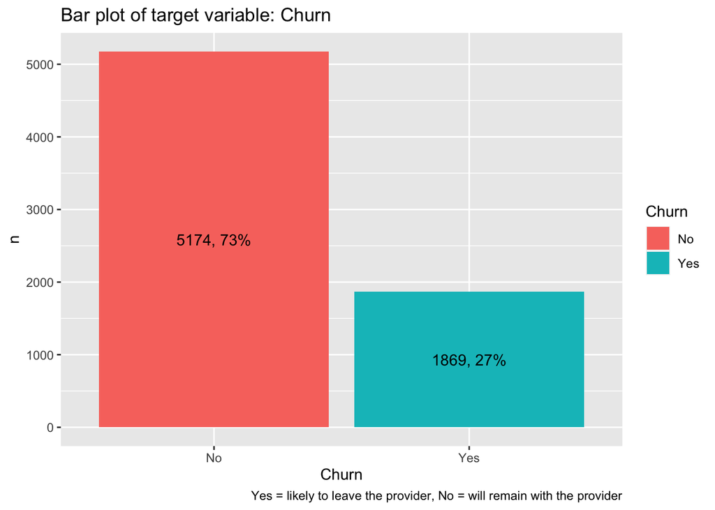

```r
telecom_plot <- telecom %>%
  dplyr::group_by(Churn) %>%
  dplyr::summarise(n = dplyr::n()) %>%
  dplyr::ungroup() %>%
  dplyr::mutate(percent = round(100*n/sum(n)),label = paste0(n,", ",percent,"%")) %>%   # shows percentage
  as.data.frame()

ggplot(telecom_plot) +
  aes(x = Churn,y = n,fill = Churn,label = label) +
  geom_col() +
  geom_text(position = position_stack(0.5)) +
  labs(
    title = "Bar plot of target variable: Churn",
    caption = "Yes = likely to leave the provider, No = will remain with the provider"
  )
```

# Converting categorical predictors to factors with levels ordered by frequency

```r
v_categorical <- names(categorical)
# Name of categorical predictors
v_categorical <- v_categorical[v_categorical != "Churn"]

for(j in v_categorical) telecom[,j] <- forcats::fct_infreq(
  f = telecom[,j]
)
```

## Sorting categorical predictors by Chi-squared test p-value

```r
v_categorical <- names(sort(sapply(
  X = v_categorical,
  FUN = function(j) chisq.test(
    x = table(telecom[,c("Churn",j)])
  )$p.value
)))
v_categorical
```

```
##  [1] "OnlineSecurity"   "TechSupport"      "InternetService"  "PaymentMethod"
##  [5] "OnlineBackup"     "DeviceProtection" "StreamingMovies"  "StreamingTV"
##  [9] "PaperlessBilling" "Dependents"       "SeniorCitizen"    "Partner"
## [13] "MultipleLines"    "PhoneService"     "gender"
```

## Visualizing categorical predictors with binary target variable

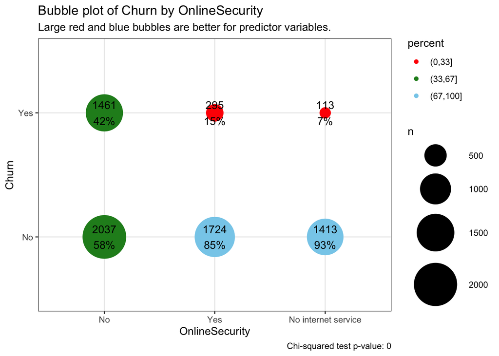

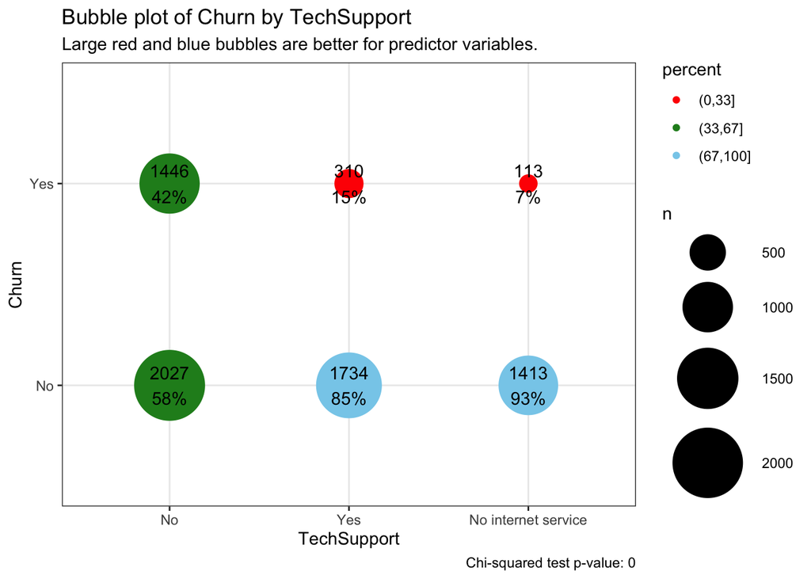

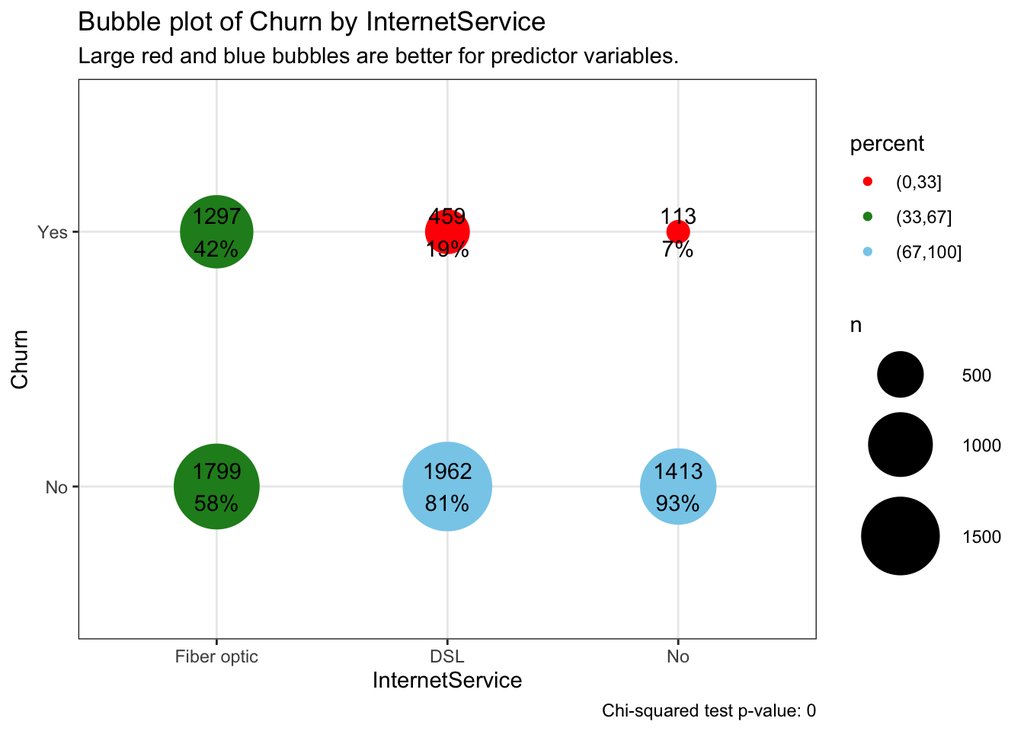

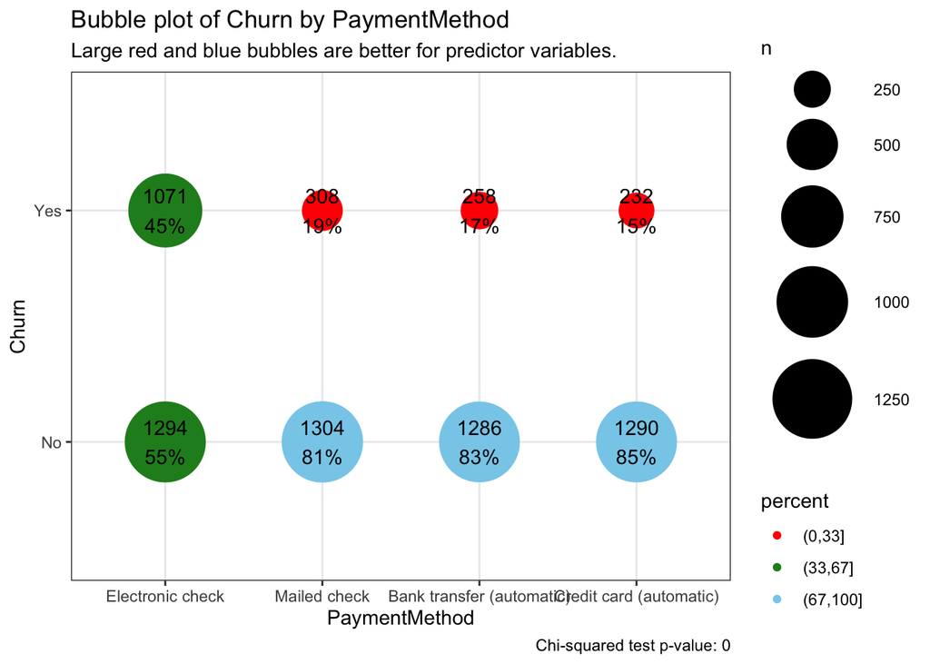

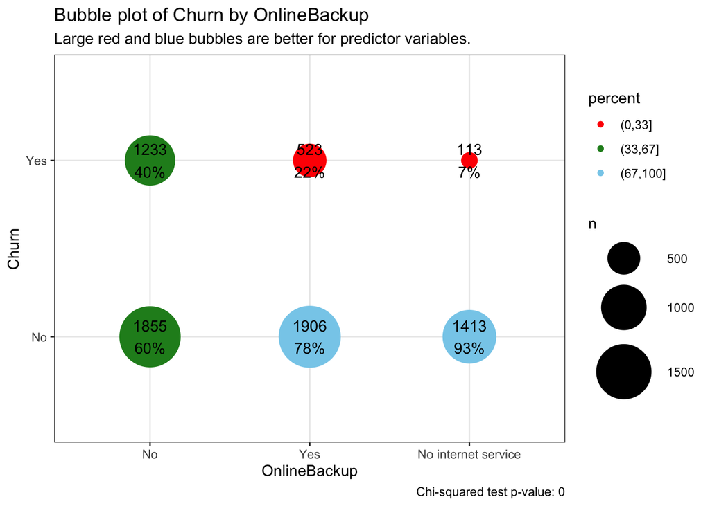

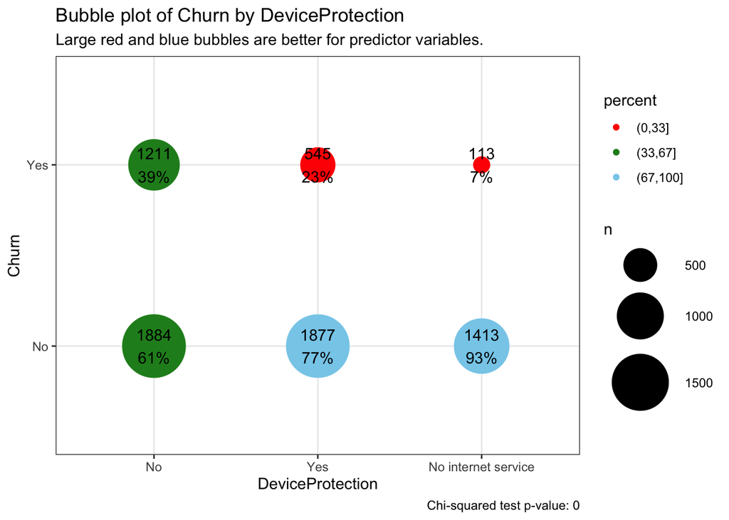

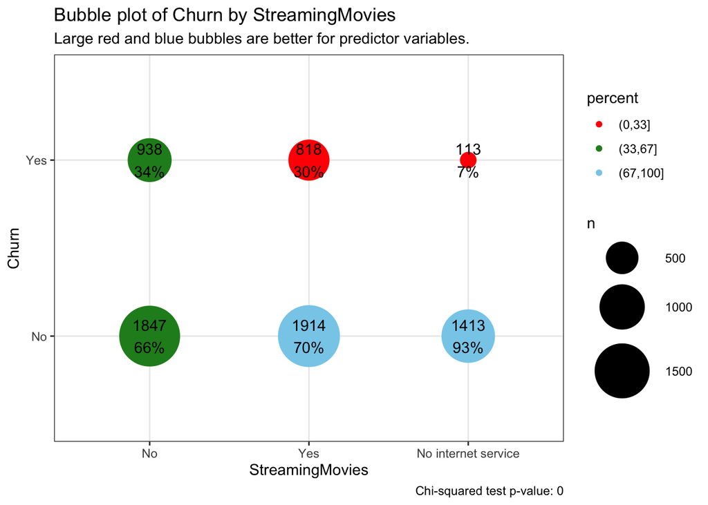

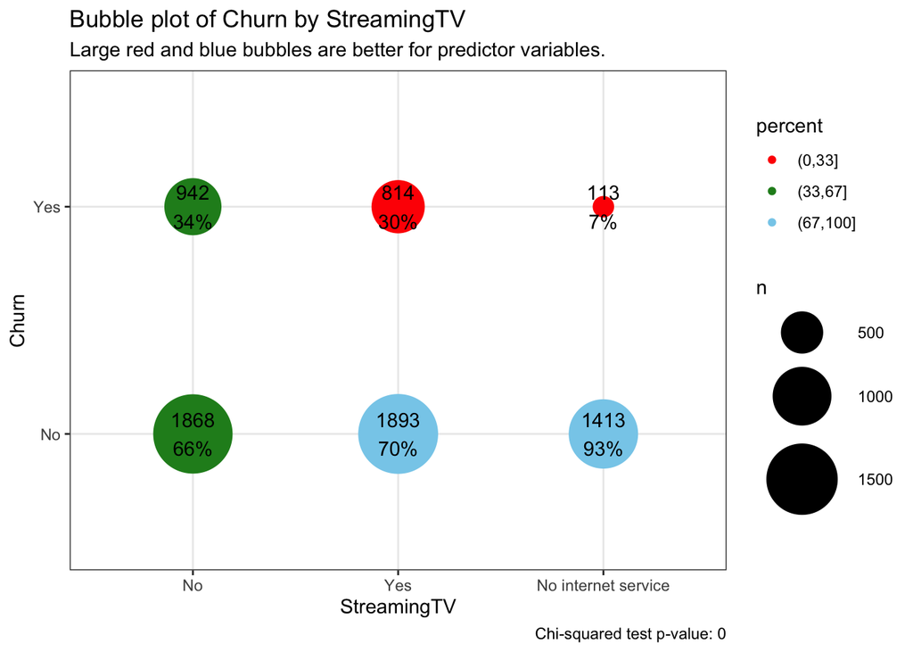

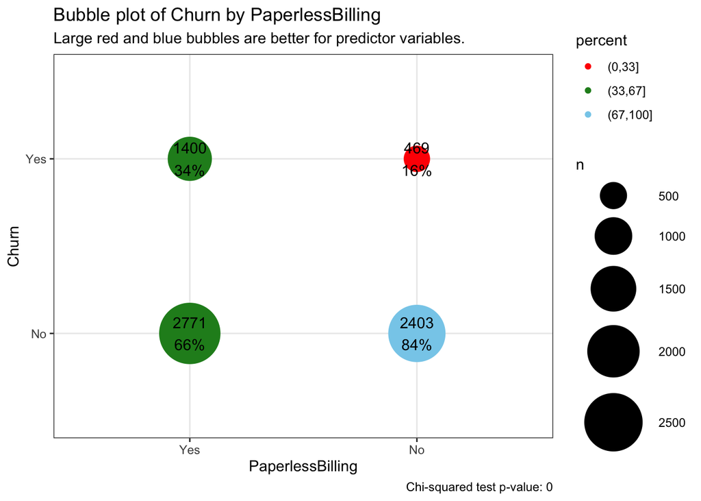

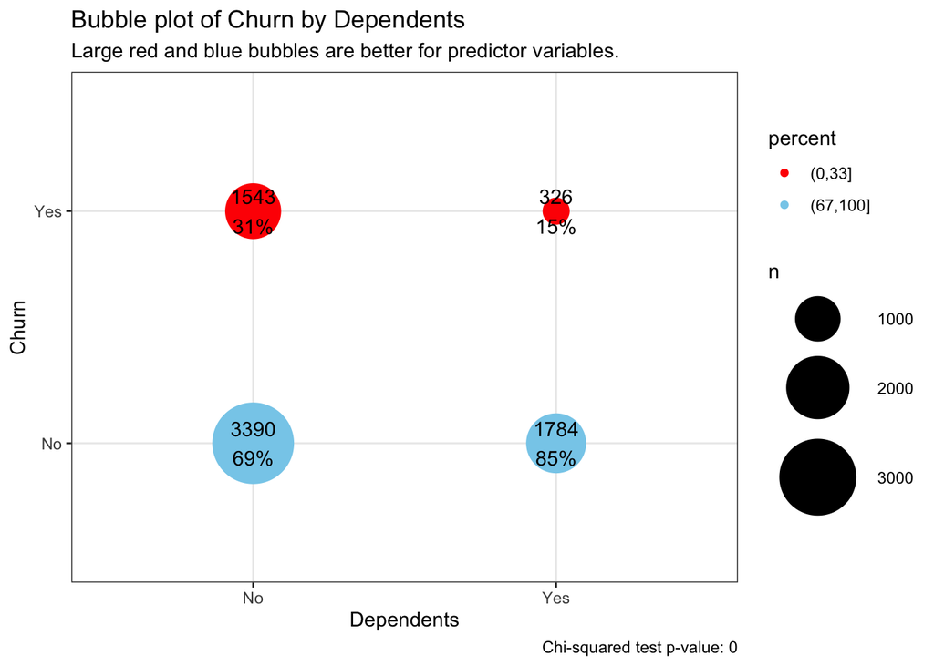

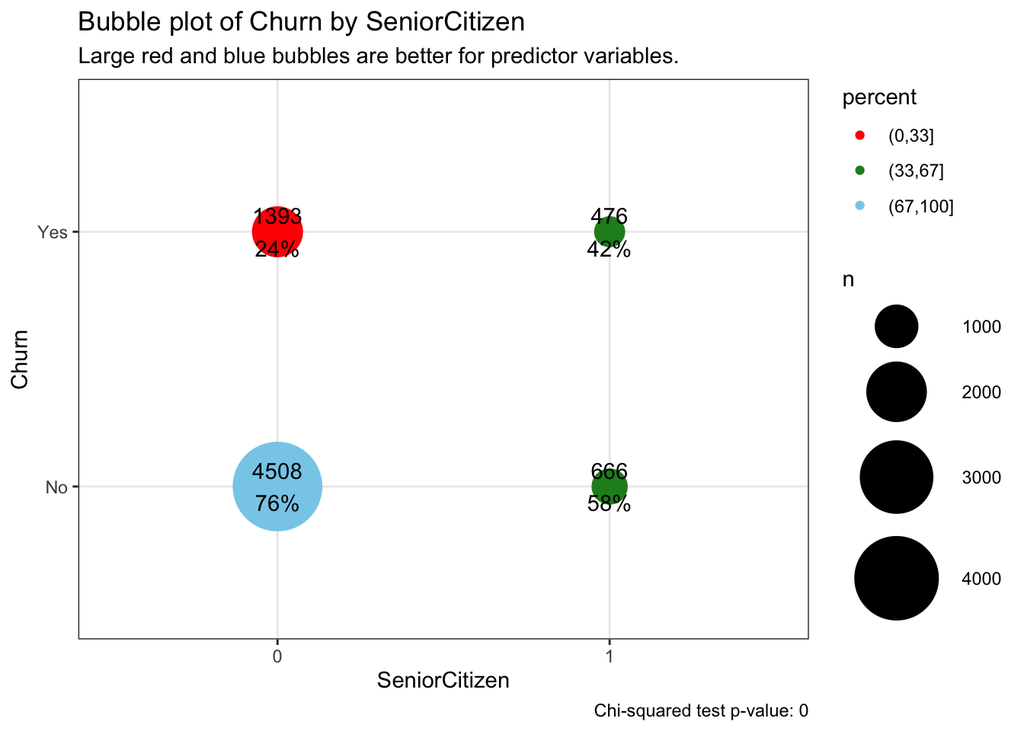

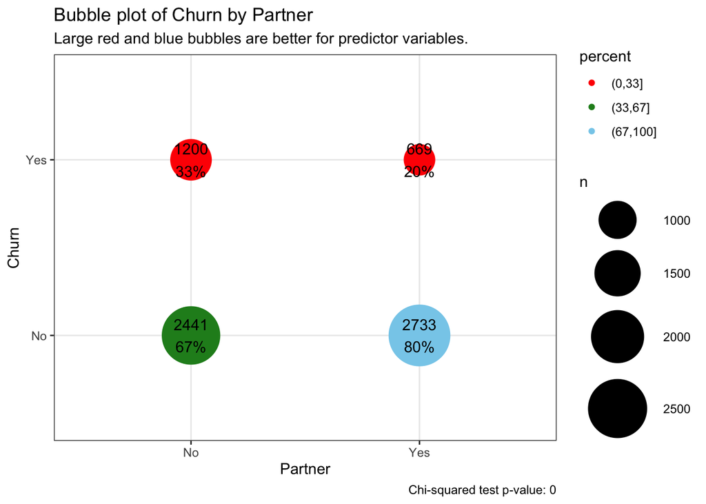

[3 more figures not shown]

```r
v_color <- c(
  "red","forestgreen","skyblue"
)
names(v_color) <- c(
  "(0,33]","(33,67]","(67,100]"    # creates 3 color categories corresponding to 3 interval range
)


for(j in v_categorical){                    # goes through for each predictor variable
  telecom_plot <- telecom %>%
    dplyr::select_("Churn",j) %>%           # selects only the target variable and jth predictor variable
    dplyr::group_by_("Churn",j) %>%         # then groups by levels of the target variable then the predictor variable
    dplyr::summarise(n = dplyr::n()) %>%    # then sums up each combination
    dplyr::group_by_(j) %>%                 # now group by the predictor variable, then calculates percentage
    dplyr::mutate(percent = round(100*n/sum(n)),label = paste0(n,"\n",percent,"%"),percent = cut(percent,breaks = c(0,33,67,100)))


  p <- ggplot(telecom_plot) +
    aes_string(x = j) +
    aes(y = Churn,label = label) +
    geom_point(aes(size = n,color = percent)) +
    geom_text() +
    scale_size_area(max_size = 20) +
    scale_color_manual(values = v_color) +
    theme_bw() +
    labs(
      title = paste0("Bubble plot of Churn by ",j),
      subtitle = "Large red and blue bubbles are better for predictor variables.",
      caption = paste0(
        "Chi-squared test p-value: ",round(chisq.test(table(telecom[,c("Churn",j)]))$p.value,22)
      )
    )
  plot(
    x = p
  )
}
```

Based on the plots and the ordering by on chi squared p value, it seems that OnlineSecurity has the most association with Churning. From an initial glance, we can automatically associate having online security with not churning.

## Binning nominal levels into binary

```r
for(j in v_categorical){
  v_table <- sort(
    x = table(
      x = telecom[,j]
    ),
    decreasing = TRUE
  )
  telecom[,j] <- as.numeric(
    x = telecom[,j] == names(v_table)[1]
  )
  v_table <- unclass(
    x = v_table
  )
  telecom_churn <- data.frame(
    level = names(v_table),
    n = v_table,
    proportion = prop.table(v_table)
  )
  print(
    x = "---------------------------------------------------------------------"
  )
  print(
    x = j
  )
  print(
    x = telecom_churn
  )
}
```

```
## [1] "---------------------------------------------------------------------"
## [1] "OnlineSecurity"
##                                   level    n proportion
## No                                   No 3498       0.50
## Yes                                 Yes 2019       0.29
## No internet service No internet service 1526       0.22
## [1] "---------------------------------------------------------------------"
## [1] "TechSupport"
##                                   level    n proportion
## No                                   No 3473       0.49
## Yes                                 Yes 2044       0.29
## No internet service No internet service 1526       0.22
## [1] "---------------------------------------------------------------------"
## [1] "InternetService"
##                   level    n proportion
## Fiber optic Fiber optic 3096       0.44
## DSL                 DSL 2421       0.34
## No                   No 1526       0.22
## [1] "---------------------------------------------------------------------"
## [1] "PaymentMethod"
##                                               level    n proportion
## Electronic check                   Electronic check 2365       0.34
## Mailed check                           Mailed check 1612       0.23
## Bank transfer (automatic) Bank transfer (automatic) 1544       0.22
## Credit card (automatic)     Credit card (automatic) 1522       0.22
## [1] "---------------------------------------------------------------------"
## [1] "OnlineBackup"
##                                   level    n proportion
## No                                   No 3088       0.44
## Yes                                 Yes 2429       0.34
## No internet service No internet service 1526       0.22
## [1] "---------------------------------------------------------------------"
## [1] "DeviceProtection"
##                                   level    n proportion
## No                                   No 3095       0.44
## Yes                                 Yes 2422       0.34
## No internet service No internet service 1526       0.22
## [1] "---------------------------------------------------------------------"
## [1] "StreamingMovies"
##                                   level    n proportion
```

[output cut: 30 more lines]

```
## [1] "MultipleLines"
##                             level    n proportion
## No                             No 3390      0.481
## Yes                           Yes 2971      0.422
## No phone service No phone service  682      0.097
## [1] "---------------------------------------------------------------------"
## [1] "PhoneService"
##     level    n proportion
## Yes   Yes 6361      0.903
## No     No  682      0.097
## [1] "---------------------------------------------------------------------"
## [1] "gender"
##         level    n proportion
## Male     Male 3555        0.5
## Female Female 3488        0.5
```

```r
summary(
  object = telecom
)
```

```
##   customerID           tenure           PhoneService   Contract
##  Length:7043        Length:7043        Min.   :0.0   Length:7043
##  Class :character   Class :character   1st Qu.:1.0   Class :character
##  Mode  :character   Mode  :character   Median :1.0   Mode  :character
##                                        Mean   :0.9
##                                        3rd Qu.:1.0
##                                        Max.   :1.0
##  PaperlessBilling PaymentMethod  MonthlyCharges     TotalCharges
##  Min.   :0.00     Min.   :0.00   Length:7043        Length:7043
##  1st Qu.:0.00     1st Qu.:0.00   Class :character   Class :character
##  Median :1.00     Median :0.00   Mode  :character   Mode  :character
##  Mean   :0.59     Mean   :0.34
##  3rd Qu.:1.00     3rd Qu.:1.00
##  Max.   :1.00     Max.   :1.00
##     Churn               gender    SeniorCitizen     Partner       Dependents
##  Length:7043        Min.   :0.0   Min.   :0.00   Min.   :0.00   Min.   :0.0
##  Class :character   1st Qu.:0.0   1st Qu.:1.00   1st Qu.:0.00   1st Qu.:0.0
##  Mode  :character   Median :1.0   Median :1.00   Median :1.00   Median :1.0
##                     Mean   :0.5   Mean   :0.84   Mean   :0.52   Mean   :0.7
##                     3rd Qu.:1.0   3rd Qu.:1.00   3rd Qu.:1.00   3rd Qu.:1.0
##                     Max.   :1.0   Max.   :1.00   Max.   :1.00   Max.   :1.0
##  MultipleLines  InternetService OnlineSecurity  OnlineBackup  DeviceProtection
##  Min.   :0.00   Min.   :0.00    Min.   :0.0    Min.   :0.00   Min.   :0.00
##  1st Qu.:0.00   1st Qu.:0.00    1st Qu.:0.0    1st Qu.:0.00   1st Qu.:0.00
##  Median :0.00   Median :0.00    Median :0.0    Median :0.00   Median :0.00
##  Mean   :0.48   Mean   :0.44    Mean   :0.5    Mean   :0.44   Mean   :0.44
##  3rd Qu.:1.00   3rd Qu.:1.00    3rd Qu.:1.0    3rd Qu.:1.00   3rd Qu.:1.00
##  Max.   :1.00   Max.   :1.00    Max.   :1.0    Max.   :1.00   Max.   :1.00
##   TechSupport    StreamingTV  StreamingMovies     target
##  Min.   :0.00   Min.   :0.0   Min.   :0.0     Min.   :0.00
##  1st Qu.:0.00   1st Qu.:0.0   1st Qu.:0.0     1st Qu.:0.00
##  Median :0.00   Median :0.0   Median :0.0     Median :0.00
##  Mean   :0.49   Mean   :0.4   Mean   :0.4     Mean   :0.27
##  3rd Qu.:1.00   3rd Qu.:1.0   3rd Qu.:1.0     3rd Qu.:1.00
##  Max.   :1.00   Max.   :1.0   Max.   :1.0     Max.   :1.00
```

After testing out both binning by conditional mean and by frequency, we stuck with frequency since both gave the same results. All of the categorical predictors had a min of 0 and a max of 1. Most of the variables had a mean within 1/3 and 2/3, anything outside was already a 2 level variable so no further binning was necessary.

## Converting numeric columns back to numbers

```r
v_numeric <- c(
  "tenure","MonthlyCharges","TotalCharges"
)
for(j in v_numeric) telecom[,j] <- as.numeric(
  x = telecom[,j]
)
```

## Capping extreme numeric values to prevents outliers from pulling model away from the rest of the data

```r
# Capping extreme values outside of the 99 percentile to the highest capped value at 99 percentile.
for(j in v_numeric){
  v_cutoffs <- quantile(
    x = telecom[,j],
    probs = c(
      0.01,0.99
    ),
    na.rm = TRUE
  )
  telecom[telecom[,j] < v_cutoffs[1] & !is.na(telecom[,j] < v_cutoffs[1]),j] <- v_cutoffs[1]
  telecom[v_cutoffs[2] < telecom[,j] & !is.na(v_cutoffs[2] < telecom[,j]),j] <- v_cutoffs[2]
}
```

# Applying transformations to numeric predictors

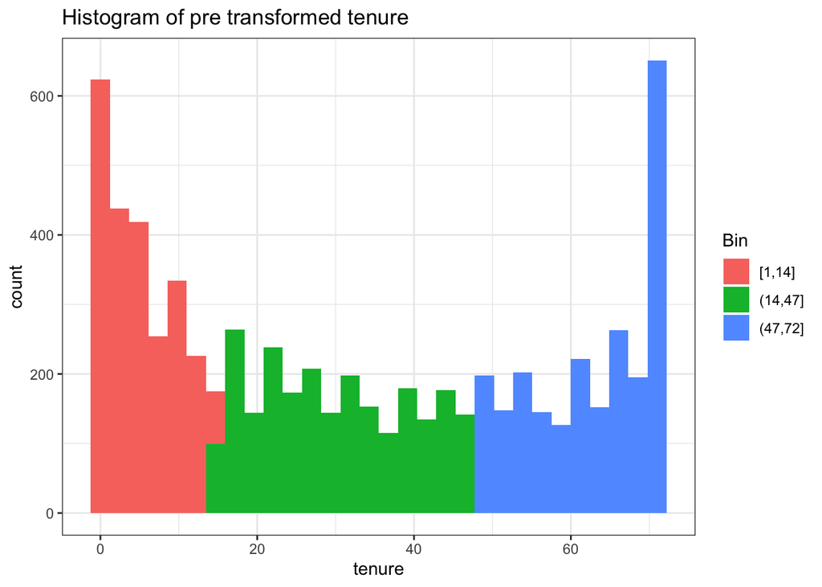

```r
telecom$Bin <- cut_number(
  x = telecom$tenure,
  n = 3,
  closed = "left"
)
telecom %>%
  dplyr::filter(!is.na(tenure)) %>%
  ggplot() +
  aes(x = tenure,fill = Bin) +
  geom_histogram() +
  theme_bw() +
  #coord_cartesian(xlim = c(0,50000)) +
  labs(
    title = "Histogram of pre transformed tenure",
  )
```

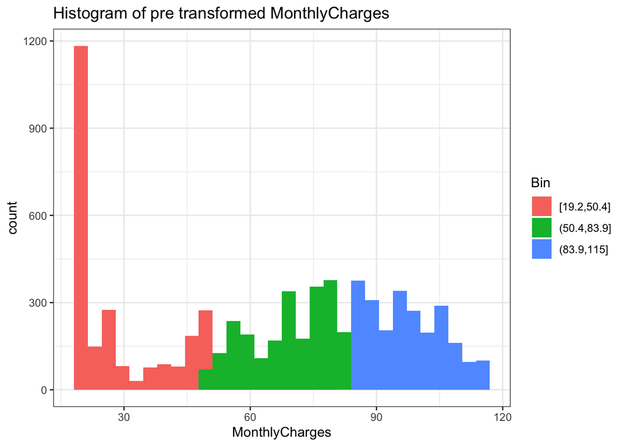

```r
telecom$Bin <- cut_number(
  x = telecom$MonthlyCharges,
  n = 3,
  closed = "left"
)
telecom %>%
  dplyr::filter(!is.na(MonthlyCharges)) %>%
  ggplot() +
  aes(x = MonthlyCharges,fill = Bin) +
  geom_histogram() +
  theme_bw() +
  #coord_cartesian(xlim = c(0,50000)) +
  labs(
    title = "Histogram of pre transformed MonthlyCharges"
  )
```

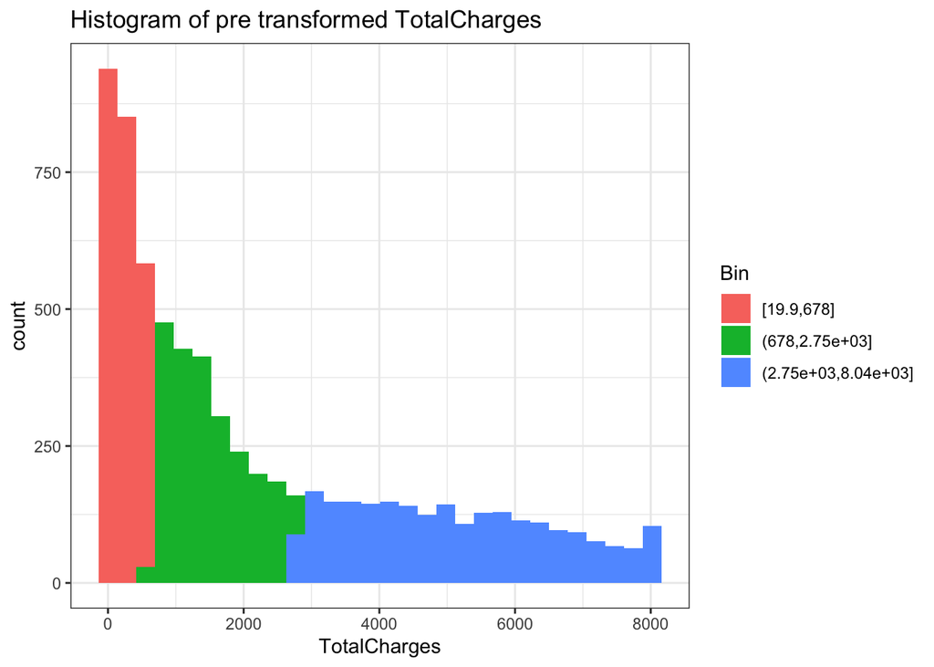

```r
telecom$Bin <- cut_number(
  x = telecom$TotalCharges,
  n = 3,
  closed = "left"
)
telecom %>%
  dplyr::filter(!is.na(TotalCharges)) %>%
  ggplot() +
  aes(x = TotalCharges,fill = Bin) +
  geom_histogram() +
  theme_bw() +
  #coord_cartesian(xlim = c(0,50000)) +
  labs(
    title = "Histogram of pre transformed TotalCharges"
  )
```

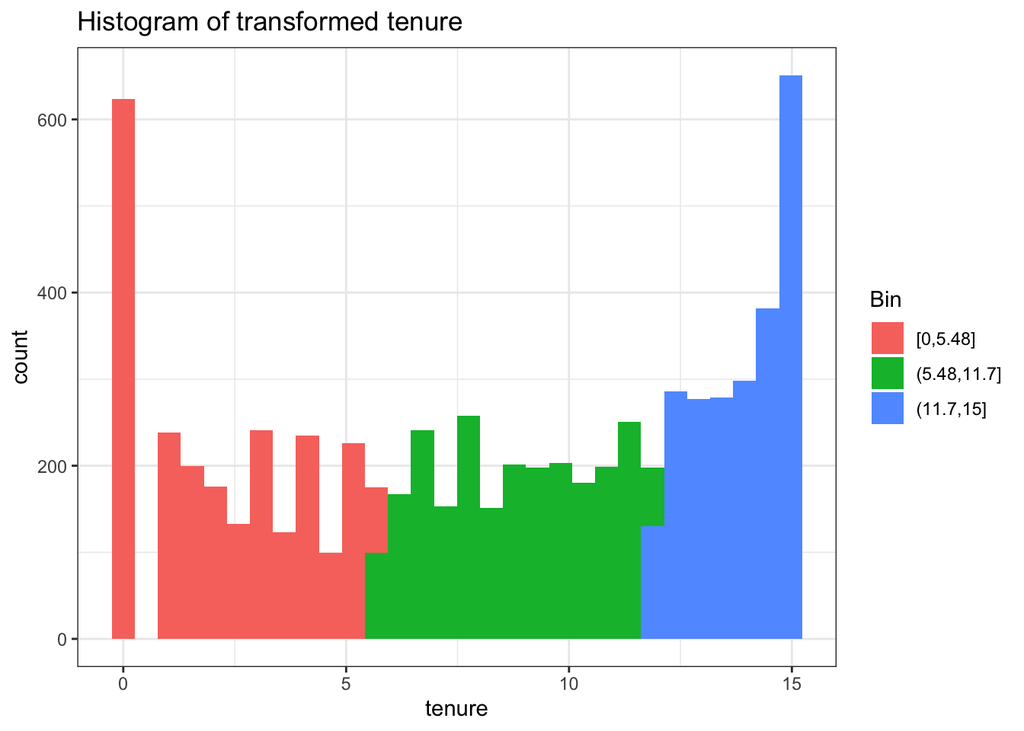

```r
v_BoxCox <- v_numeric
preProcess_BoxCox <- caret::preProcess(
  x = telecom[,v_BoxCox],
  method = "BoxCox"
)

telecom[,v_BoxCox] <- predict(
  object = preProcess_BoxCox,
  newdata = telecom[,v_BoxCox]
)


telecom$Bin <- cut_number(
  x = telecom$tenure,
  n = 3,
  closed = "left"
)
telecom %>%
  dplyr::filter(!is.na(tenure)) %>%
  ggplot() +
  aes(x = tenure,fill = Bin) +
  geom_histogram() +
  theme_bw() +
  #coord_cartesian(xlim = c(0,50000)) +
  labs(
    title = "Histogram of transformed tenure",
  )
```

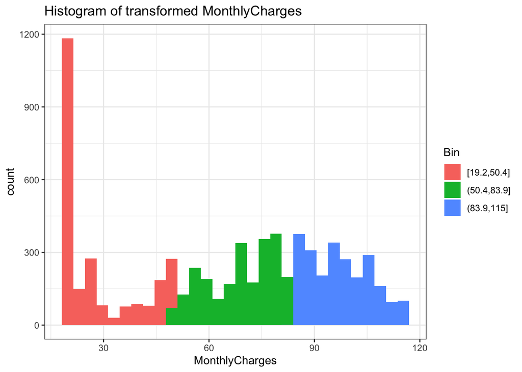

```r
telecom$Bin <- cut_number(
  x = telecom$MonthlyCharges,
  n = 3,
  closed = "left"
)
telecom %>%
  dplyr::filter(!is.na(MonthlyCharges)) %>%
  ggplot() +
  aes(x = MonthlyCharges,fill = Bin) +
  geom_histogram() +
  theme_bw() +
  #coord_cartesian(xlim = c(0,50000)) +
  labs(
    title = "Histogram of transformed MonthlyCharges"
  )
```

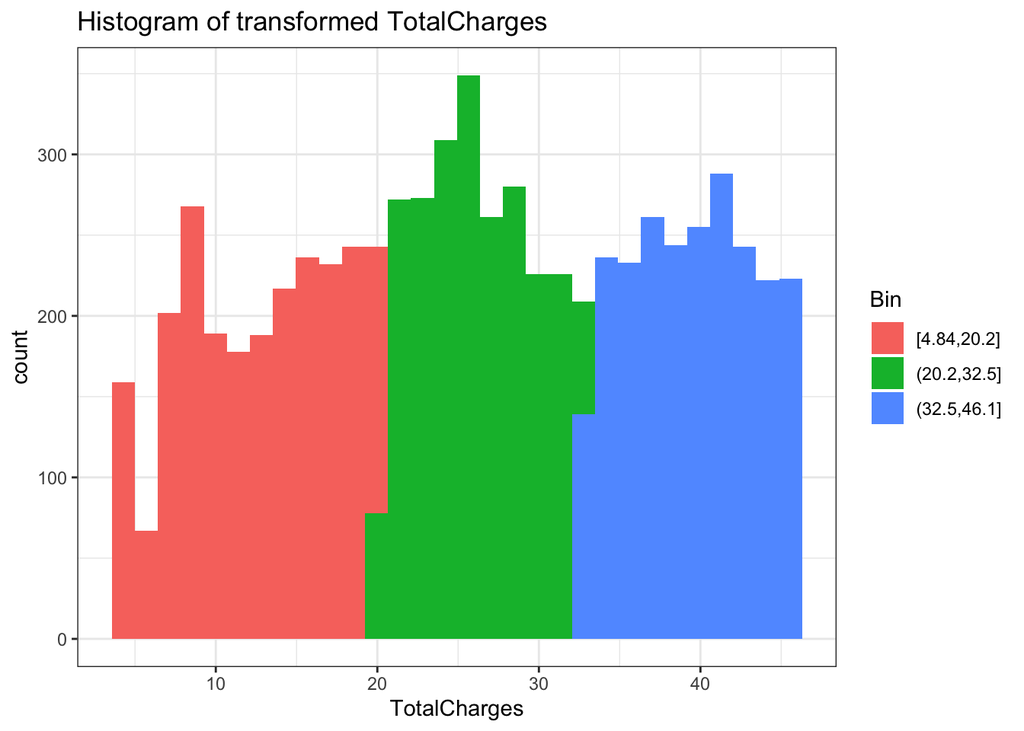

```r
telecom$Bin <- cut_number(
  x = telecom$TotalCharges,
  n = 3,
  closed = "left"
)
telecom %>%
  dplyr::filter(!is.na(TotalCharges)) %>%
  ggplot() +
  aes(x = TotalCharges,fill = Bin) +
  geom_histogram() +
  theme_bw() +
  #coord_cartesian(xlim = c(0,50000)) +
  labs(
    title = "Histogram of transformed TotalCharges"
  )
```